# Project Code - Data Cleaning and Preparation, Variable Selection, XGBoost

Team Too-pullz

Author

Gabrielle Bliss

Published

June 7, 2023

Abstract

*This file contains the code for our project on Food Insecurity Classification, as part of the STAT303-3 course in Spring 2023*.

```python
# Importing pertinent libraries and functions
import pandas as pd
import numpy as np
import seaborn as sns
import matplotlib.pyplot as plt
import xgboost as xgb
from sklearn.metrics import mean_squared_error
from sklearn.model_selection import cross_val_score,train_test_split, KFold, cross_val_predict
from sklearn.metrics import mean_squared_error,r2_score,roc_curve,auc,precision_recall_curve, accuracy_score, \
recall_score, precision_score, confusion_matrix
from sklearn.tree import DecisionTreeRegressor,DecisionTreeClassifier
from sklearn.ensemble import RandomForestRegressor,RandomForestClassifier
from sklearn.model_selection import GridSearchCV, RandomizedSearchCV, ParameterGrid, StratifiedKFold
from sklearn.ensemble import BaggingRegressor,BaggingClassifier,AdaBoostRegressor,AdaBoostClassifier
from sklearn.linear_model import LinearRegression,LogisticRegression
from sklearn.neighbors import KNeighborsRegressor
import itertools as it
import xgboost as xgb
```

```python
# Uploading full dataset
food_data = pd.read_csv('/content/dec21pub.csv')
```

```python
food_data.shape
```

## 1 Data Cleaning

*From documentation:* “Measures that combine information from multiple items (`HRFS12M1` and following) are generally considered to be more reliable measures of food security and food insecurity”  
Thus, we will use one of these as the response and drop the rest. Additionlly, using documentation, we will drop all variables after the first variable referring to the Food Security Supplement Survey, as the dataset is ordered in this way, and we are not using these questions as variables.

```python
# Index of first question/variable in food security supplement
list(food_data.columns).index('HES1A')
```

```
391
```

```python
# Index of first "response" type variable created from Food Security Supplement survey responses. All these will be dropped except for our pertinent repsonse variable
list(food_data.columns).index('HRFS12M1')
```

```
487
```

`HRINTSTA` informs whether or not the interview took place. We only want interviews that are complete! Thus, we only want variables with complete interviews (variable value = 1).

```python
# HRINTSTA 1's mean that the interview took place. We will filter for this.
# HRSUPINT 1's mean that the food security supplement survey took place, and response is most likely present. We will filter for this as well.

food_data = food_data.loc[food_data['HRINTSTA']==1, :]
food_data = food_data.loc[food_data['HRSUPINT']==1,:]
food_data.shape

# These are households that completed the interview and the food security supplement survey. Should be no actual empty values except for in response.
```

```
(71571, 507)
```

Dropping “missing” response variables based on `HRFS12CX` variable value being = to -5.

```python
# Response variable: -5 indicates a missing val, so these values are dropped
to_drop = list(food_data.loc[food_data['HRFS12CX']==-5, :].index) #38 vals were dropped here
food_data = food_data.drop(to_drop, axis=0)
food_data.shape
```

```
(71533, 507)
```

Encoding response variable

```python
# Changing 1 and 2 to 0 and 1 for repsonse variable encoding
food_data['y'] = food_data['HRFS12CX'].apply(lambda x: 0 if 1 == x
                                              else 1)
response = pd.DataFrame(food_data.y.value_counts())
response
```

|  | y |
| --- | --- |
| 0 | 59124 |
| 1 | 12409 |

### 1.1 Distribution of Response

```
Proportion of Food Insecure Houses: 0.17347238337550502
Proportion of Food Secure Houses: 0.826527616624495
```

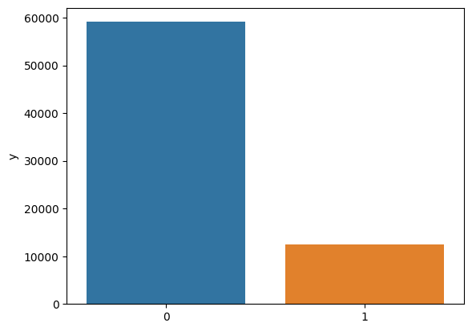

```python
print('Proportion of Food Insecure Houses:', (response.loc[1, 'y']/response.y.sum()))
print('Proportion of Food Secure Houses:', (response.loc[0, 'y']/response.y.sum()), '\n\n')
sns.barplot(response, x = response.index, y = 'y')
```

### 1.2 Continued Data Preparation: Train and Test, Distributions

Creating train and test sets based on a 80/20 split of the predictor and response datasets, `X` and `y`. `X` drops predictors from Food Supplement Survey as well as the repsonse variables created from this second survey (using indices found above). `y` consists of encoded reponse variable.

```python
# Splitting the data into train/test
y = food_data.y
X = food_data.iloc[:, 0:391]
X = X.drop('FILLER', axis = 1)

X_train, X_test, y_train, y_test = train_test_split(X, y, test_size = 0.2, random_state = 45)
X_train
```

```python
# Distribution of responses in train data
print('Insecure:', y_train.sum()/len(y_train))
print('Secure:', (len(y_train) - y_train.sum())/len(y_train))
```

```
Insecure: 0.1726837451508056
Secure: 0.8273162548491945
```

```python
# Distribution of responses in test data
print('Insecure:', y_test.sum()/len(y_test))
print('Secure:', (len(y_test) - y_test.sum())/len(y_test))
```

```
Insecure: 0.17662682602921648
Secure: 0.8233731739707836
```

```python
# For possible use in for loop for variable selection, a full train dataset with the predictors and response
train = pd.concat([X_train,y_train], axis=1)
```

## 2 Variable Selection: Performed using Random Forest

Baseline Random Forest Classification Model

```python
model = RandomForestClassifier(n_jobs=-1).fit(X_train, y_train)
```

Predictor Importances from Random Forest

```python
importances = np.mean([tree.feature_importances_ for tree in model.estimators_], axis=0)
importances = pd.DataFrame(importances)
```

```python
df = pd.concat([pd.DataFrame(model.feature_names_in_, columns = ['Predictors']), importances], axis = 1)
df = df.rename(columns = {0: 'Importances'})
df = df[df.Importances > 0.000000000000]
df.set_index('Predictors').sort_values(by = 'Importances', ascending = False)
```

| Predictors | Importances |
| --- | --- |
| HEFAMINC | 8.729361e-02 |
| QSTNUM | 2.876774e-02 |
| HRHHID | 2.841662e-02 |
| HWHHWGT | 2.655451e-02 |
| PWFMWGT | 2.470734e-02 |
| ... | ... |
| PEAFWHN4 | 2.219459e-06 |
| PULKDK2 | 1.866884e-06 |
| PTOT | 1.014999e-06 |
| PTERN2 | 4.870061e-07 |
| HUTYPB | 8.711871e-09 |

375 rows × 1 columns

```python
# Minimum and Maximum Importances to help gauge threshold values to loop through
print('Minimum Importance:',  df.Importances.min())
print('Maximum Importance:', df.Importances.max())
```

```
Minimum Importance: 8.711870964163109e-09
Maximum Importance: 0.08729360802874236
```

```python
# Testing loop logic
for importance in [10**-9, 10**-6, 10**-5, 10**-4, 10**-3, 10**-2]:
  print(importance)
```

```
1e-09
1e-06
1e-05
0.0001
0.001
0.01
```

```python
# Testing loop coding logic
df[df.Importances > 0.001]
```

|  | Predictors | Importances |
| --- | --- | --- |
| 0 | HRHHID | 0.028417 |
| 3 | HURESPLI | 0.006569 |
| 4 | HUFINAL | 0.002814 |
| 5 | HETENURE | 0.018152 |
| 6 | HEHOUSUT | 0.005912 |
| ... | ... | ... |
| 384 | PECERT1 | 0.001528 |
| 385 | PECERT2 | 0.001861 |
| 386 | PECERT3 | 0.001428 |
| 387 | PXCERT1 | 0.002607 |
| 388 | PXCERT2 | 0.001379 |

164 rows × 2 columns

```python
# Testing loop coding logic
train.loc[:, (df[df.Importances > 0.001]).Predictors.to_list() + ['y']]
```

|  | HRHHID | HURESPLI | HUFINAL | HETENURE | HEHOUSUT | HETELHHD | HETELAVL | HEPHONEO | HEFAMINC | HWHHWGT | ... | PEDISOUT | PRDISFLG | HXFAMINC | PRDASIAN | PECERT1 | PECERT2 | PECERT3 | PXCERT1 | PXCERT2 | y |
| --- | --- | --- | --- | --- | --- | --- | --- | --- | --- | --- | --- | --- | --- | --- | --- | --- | --- | --- | --- | --- | --- |
| 112251 | 507340501120403 | 1 | 201 | 3 | 1 | 1 | -1 | 1 | 13 | 34491316 | ... | 2 | 2 | 42 | -1 | 2 | -1 | -1 | 0 | 0 | 0 |
| 89743 | 578660581951003 | 1 | 201 | 3 | 5 | 1 | -1 | 1 | 3 | 12853838 | ... | 2 | 2 | 0 | -1 | 2 | -1 | -1 | 0 | 0 | 0 |
| 114059 | 967582201340105 | 1 | 201 | 2 | 5 | 1 | -1 | 1 | 10 | 37756466 | ... | 2 | 2 | 23 | -1 | 2 | -1 | -1 | 0 | 0 | 0 |
| 33973 | 410100031131678 | 1 | 201 | 2 | 1 | 1 | -1 | 1 | 16 | 40579130 | ... | 2 | 2 | 0 | -1 | 2 | -1 | -1 | 20 | 0 | 0 |
| 20904 | 219010610013449 | 4 | 201 | 1 | 1 | 1 | -1 | 1 | 16 | 45467838 | ... | 2 | 2 | 0 | -1 | 2 | -1 | -1 | 20 | 0 | 0 |
| ... | ... | ... | ... | ... | ... | ... | ... | ... | ... | ... | ... | ... | ... | ... | ... | ... | ... | ... | ... | ... | ... |
| 18379 | 310946170108105 | 1 | 201 | 3 | 1 | 1 | -1 | 1 | 13 | 21372705 | ... | -1 | -1 | 0 | -1 | -1 | -1 | -1 | -1 | -1 | 0 |
| 94077 | 411809460586216 | 1 | 201 | 1 | 1 | 1 | -1 | 1 | 11 | 33387906 | ... | 2 | 2 | 0 | -1 | 2 | -1 | -1 | 0 | 0 | 0 |
| 8856 | 40710040307671 | 1 | 1 | 2 | 1 | 1 | -1 | 1 | 1 | 40151439 | ... | -1 | -1 | 0 | -1 | -1 | -1 | -1 | -1 | -1 | 0 |
| 98134 | 28720188901004 | 1 | 201 | 1 | 1 | 1 | -1 | 1 | 15 | 28083647 | ... | 2 | 2 | 0 | -1 | 1 | 2 | 2 | 0 | 0 | 0 |
| 9472 | 12076304105461 | 2 | 1 | 1 | 1 | 1 | -1 | 1 | 14 | 10070023 | ... | 2 | 2 | 0 | -1 | 2 | -1 | -1 | 20 | 0 | 0 |

57226 rows × 165 columns

The follwoing code is the for loop through importance thresholds to determine which subset produces the highest cross validated accuracy on train data

```python
from sklearn.model_selection import cross_val_score,train_test_split, cross_val_predict
importance_thresholds = [10**-9, 10**-6, 10**-5, 10**-4, 10**-3, 10**-2]
accuracy_scores = []
for importance in importance_thresholds:
  threshold = df[df.Importances > importance]
  plist = threshold.Predictors.to_list() + ['y']
  new = train.loc[:, plist]
  new_x = new.drop('y', axis = 1)
  # Defining the evaluation procedure
  cv = KFold(n_splits = 7, shuffle = True)
  # Defining the grid search procedure
  model = RandomForestClassifier(n_jobs=-1)
  cv_score = cross_val_score(model, new_x, new.y, cv = cv, n_jobs = -1, scoring = 'accuracy')
  accuracy_scores.append(cv_score.mean())
```

```python
# Accuracy scores from loop
accuracy_scores
```

```
[0.8642051366229538,
 0.8645545423146009,
 0.8634536783168715,
 0.8647293060745727,
 0.8692551995034535,
 0.9137456045633033]
```

```python
# Threshold for optimal predictors
opt_importance_thresh = importance_thresholds[np.argmax(accuracy_scores)]
opt_importance_thresh
```

```
0.01
```

Optimal Predictors from this RF Feature Importance Algorithm

```python
len(df[df.Importances > opt_importance_thresh]) # 22 predictors here
threshold = df[df.Importances > opt_importance_thresh]
plist = threshold.Predictors.to_list()
plist.remove('HRHHID')
plist = plist
plist
```

```
['HETENURE',
 'HEFAMINC',
 'HWHHWGT',
 'HRNUMHOU',
 'HRHTYPE',
 'HRMIS',
 'HRHHID2',
 'GEDIV',
 'GESTFIPS',
 'GTCBSA',
 'GTCO',
 'GTCBSASZ',
 'GTCSA',
 'PRTAGE',
 'PEEDUCA',
 'PWFMWGT',
 'PWLGWGT',
 'PWSSWGT',
 'PWVETWGT',
 'QSTNUM',
 'PWCMPWGT',
 'HXFAMINC']
```

Variable independently defining the predictor list so that when document has to be rerun, loop processes do not have to be rerun

```python
filter = ['HETENURE',
 'HEFAMINC',
 'HWHHWGT',
 'HRNUMHOU',
 'HRHTYPE',
 'HRMIS',
 'HRHHID2',
 'GEDIV',
 'GESTFIPS',
 'GTCBSA',
 'GTCO',
 'GTCBSASZ',
 'GTCSA',
 'PRTAGE',
 'PEEDUCA',
 'PWFMWGT',
 'PWLGWGT',
 'PWSSWGT',
 'PWVETWGT',
 'QSTNUM',
 'PWCMPWGT',
 'HXFAMINC']
```

Filtering train and test datasets for variables selected

```python
X_train_f = X_train.loc[:, filter]
X_test_f = X_test.loc[:, filter]
X_train_f
```

|  | HETENURE | HEFAMINC | HWHHWGT | HRNUMHOU | HRHTYPE | HRMIS | HRHHID2 | GEDIV | GESTFIPS | GTCBSA | ... | GTCSA | PRTAGE | PEEDUCA | PWFMWGT | PWLGWGT | PWSSWGT | PWVETWGT | QSTNUM | PWCMPWGT | HXFAMINC |
| --- | --- | --- | --- | --- | --- | --- | --- | --- | --- | --- | --- | --- | --- | --- | --- | --- | --- | --- | --- | --- | --- |
| 112251 | 3 | 13 | 34491316 | 3 | 4 | 5 | 12111 | 6 | 47 | 0 | ... | 0 | 26 | 39 | 29445158 | 0 | 29445158 | 30622270 | 56171 | 30649540 | 42 |
| 89743 | 3 | 3 | 12853838 | 2 | 4 | 5 | 12012 | 8 | 35 | 22140 | ... | 0 | 29 | 35 | 12853838 | 0 | 12853838 | 11304924 | 44370 | 11504978 | 0 |
| 114059 | 2 | 10 | 37756466 | 5 | 1 | 6 | 12011 | 3 | 17 | 44100 | ... | 0 | 28 | 40 | 37756466 | 0 | 37756466 | 37957235 | 57193 | 37991036 | 23 |
| 33973 | 2 | 16 | 40579130 | 2 | 1 | 7 | 12011 | 3 | 18 | 26900 | ... | 0 | 31 | 43 | 40579130 | 60302779 | 40579130 | 39956488 | 17188 | 40140673 | 0 |
| 20904 | 1 | 16 | 45467838 | 3 | 1 | 8 | 12011 | 5 | 24 | 12580 | ... | 548 | 53 | 44 | 45467838 | 67567663 | 45467838 | 45859570 | 10727 | 45859610 | 0 |
| ... | ... | ... | ... | ... | ... | ... | ... | ... | ... | ... | ... | ... | ... | ... | ... | ... | ... | ... | ... | ... | ... |
| 18379 | 3 | 13 | 21372705 | 4 | 1 | 2 | 13011 | 6 | 1 | 13820 | ... | 0 | 10 | -1 | 23960728 | 0 | 23960728 | 0 | 9349 | 0 | 0 |
| 94077 | 1 | 11 | 33387906 | 2 | 6 | 5 | 12012 | 9 | 6 | 31080 | ... | 348 | 37 | 43 | 33387906 | 0 | 33387906 | 32546139 | 46475 | 33223156 | 0 |
| 8856 | 2 | 1 | 40151439 | 2 | 4 | 2 | 13011 | 6 | 47 | 34980 | ... | 0 | 10 | -1 | 49328281 | 0 | 49328281 | 0 | 4651 | 0 | 0 |
| 98134 | 1 | 15 | 28083647 | 2 | 1 | 5 | 12011 | 7 | 40 | 36420 | ... | 0 | 48 | 42 | 28083647 | 0 | 22532325 | 22323298 | 48327 | 22715863 | 0 |
| 9472 | 1 | 14 | 10070023 | 2 | 1 | 3 | 13111 | 8 | 16 | 14260 | ... | 0 | 55 | 40 | 10070023 | 15682620 | 10520687 | 13552245 | 4922 | 10858623 | 0 |

57226 rows × 22 columns

## 3 Model Development: XGBoost

```python
import xgboost as xgb
from sklearn.model_selection import GridSearchCV, RandomizedSearchCV
```

Again, initializing train and test with selected variables

```python
# From independently defined predictor list
X_train_filtered = X_train.loc[:, filter]
X_test_filtered = X_test.loc[:, filter]

# Filtering using predictor list from for loop
## X_train_filtered = X_train.loc[:, plist]
## X_test_filtered = X_test.loc[:, plist]
```

```python
# Exporting relevant datasets to individual csvs to share to the rest of my group
X_train_filtered.to_csv('X_train_tree.csv')
y_train.to_csv('y_train_tree.csv')
X_test_filtered.to_csv('X_test_tree.csv')
y_test.to_csv('y_test_tree.csv')
```

Baseline XGBoost Model Performance (with Selected Variables)

```python
baseline_model = xgb.XGBClassifier().fit(X_train_filtered, y_train)
```

```
Train Scores
Accuracy:  92.47894313773459
Recall:  66.535114349322
Precision:  86.83306920232435
```

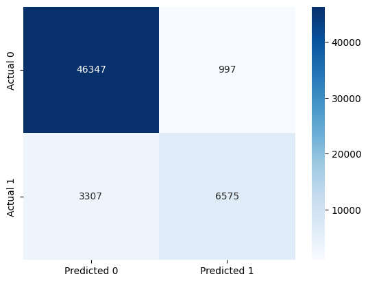

```python
#Computing the accuracy and recall
print('Train Scores')
print("Accuracy: ",accuracy_score(y_train, baseline_model.predict(X_train_filtered))*100)
print("Recall: ", recall_score(y_train, baseline_model.predict(X_train_filtered))*100)
print("Precision: ", precision_score(y_train, baseline_model.predict(X_train_filtered))*100)

#Confusion matrix
cm = pd.DataFrame(confusion_matrix(y_train, baseline_model.predict(X_train_filtered)),
                  columns=['Predicted 0', 'Predicted 1'], index = ['Actual 0', 'Actual 1'])
sns.heatmap(cm, annot=True, cmap='Blues', fmt='g');
```

```
Test Scores
Accuracy:  88.37631928426644
Recall:  51.602690937870996
Precision:  74.77064220183486
```

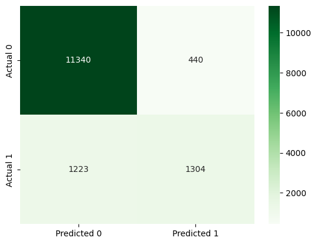

```python
#Computing the accuracy and recall
print('Test Scores')
print("Accuracy: ", accuracy_score(y_test, baseline_model.predict(X_test_filtered))*100)
print("Recall: ", recall_score(y_test, baseline_model.predict(X_test_filtered))*100)
print("Precision: ", precision_score(y_test, baseline_model.predict(X_test_filtered))*100)

#Confusion matrix
cm = pd.DataFrame(confusion_matrix(y_test, baseline_model.predict(X_test_filtered)),
                  columns=['Predicted 0', 'Predicted 1'], index = ['Actual 0', 'Actual 1'])
sns.heatmap(cm, annot=True, cmap='Greens', fmt='g');
```

Baseline XGBoost Model Performance (with *all* predictors for comparison)

```python
# Fitting model with all pred
modelall = xgb.XGBClassifier().fit(X_train, y_train)
```

```
Test Scores
Accuracy:  88.59299643531139
Recall:  52.98773248911753
Precision:  75.09814918676389
```

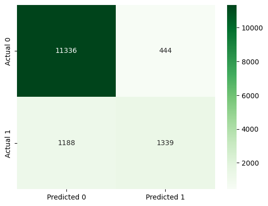

```python
#Computing the accuracy and recall
print('Test Scores')
print("Accuracy: ", accuracy_score(y_test, modelall.predict(X_test))*100)
print("Recall: ", recall_score(y_test, modelall.predict(X_test))*100)
print("Precision: ", precision_score(y_test, modelall.predict(X_test))*100)

#Confusion matrix
cm = pd.DataFrame(confusion_matrix(y_test, modelall.predict(X_test)),
                  columns=['Predicted 0', 'Predicted 1'], index = ['Actual 0', 'Actual 1'])
sns.heatmap(cm, annot=True, cmap='Greens', fmt='g');
```

A. XGBoost Models Refitting on Accuracy

```python
# Defining scale_pos_weight parameter
scale_pos_weight = (len(y_train) - sum(y_train)) / sum(y_train)
scale_pos_weight
```

```
4.790933009512244
```

*Search A.1*

```python
import xgboost as xgb
from sklearn.model_selection import GridSearchCV, RandomizedSearchCV

# Optimal estimators search
param_grid = {'n_estimators': [100, 200, 1000, 4000],
              'learning_rate': [0.01, 0.1, 0.5, 1.0],
              'max_depth': range(2, 23, 2),
              'subsample': [0.3, 0.5, 0.6],
              'gamma': range(1, 10, 2),
              'reg_lambda': [1, 5, 10],
              'colsample_bytree': [0.25, 0.5, 0.75],
              'scale_pos_weight': [scale_pos_weight]}

# Defining the evaluation procedure
cv = KFold(n_splits = 3, shuffle = True)

# Defining the grid search procedure
grid_search = RandomizedSearchCV(estimator = xgb.XGBClassifier(), param_distributions = param_grid, n_iter = 15, n_jobs = -1, cv = cv,
                          verbose = True, scoring = 'accuracy')
# execute the grid search
grid_result = grid_search.fit(X_train_filtered, y_train)

# summarize the best score and configuration
print("Best: %f using %s" % (grid_result.best_score_, grid_result.best_params_))
```

```
Fitting 3 folds for each of 15 candidates, totalling 45 fits
Best: 0.892636 using {'subsample': 0.5, 'scale_pos_weight': 4.790933009512244, 'reg_lambda': 1, 'n_estimators': 1000, 'max_depth': 16, 'learning_rate': 0.1, 'gamma': 7, 'colsample_bytree': 0.75}
```

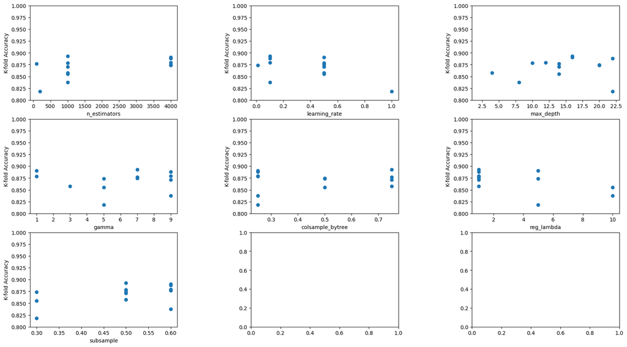

```python
cv_results = pd.DataFrame(grid_search.cv_results_)
cv_results.head(); # to analyze column names for use

fig, axes = plt.subplots(3, 3, figsize=(20,11))
plt.subplots_adjust(wspace = 0.5)
axes[0, 0].plot(cv_results.param_n_estimators, cv_results.mean_test_score, 'o')
axes[0, 0].set_ylim([0.8, 1])
axes[0, 0].set_xlabel('n_estimators')
axes[0, 0].set_ylabel('K-fold Accuracy')
axes[0, 1].plot(cv_results.param_learning_rate, cv_results.mean_test_score, 'o')
axes[0, 1].set_ylim([0.8, 1])
axes[0, 1].set_xlabel('learning_rate')
axes[0, 1].set_ylabel('K-fold Accuracy');
axes[0, 2].plot(cv_results.param_max_depth, cv_results.mean_test_score, 'o')
axes[0, 2].set_ylim([0.8, 1])
axes[0, 2].set_xlabel('max_depth')
axes[0, 2].set_ylabel('K-fold Accuracy');
axes[1, 0].plot(cv_results.param_gamma, cv_results.mean_test_score, 'o')
axes[1, 0].set_ylim([0.8, 1])
axes[1, 0].set_xlabel('gamma')
axes[1, 0].set_ylabel('K-fold Accuracy');
axes[1, 1].plot(cv_results.param_colsample_bytree, cv_results.mean_test_score, 'o')
axes[1, 1].set_ylim([0.8, 1])
axes[1, 1].set_xlabel('colsample_bytree')
axes[1, 1].set_ylabel('K-fold Accuracy');
axes[1, 2].plot(cv_results.param_reg_lambda, cv_results.mean_test_score, 'o')
axes[1, 2].set_ylim([0.8, 1])
axes[1, 2].set_xlabel('reg_lambda')
axes[1, 2].set_ylabel('K-fold Accuracy');
axes[2, 0].plot(cv_results.param_subsample, cv_results.mean_test_score, 'o')
axes[2, 0].set_ylim([0.8, 1])
axes[2, 0].set_xlabel('subsample')
axes[2, 0].set_ylabel('K-fold Accuracy');
```

*Model A.1, from Search A.1*

```python
# Fitting model with optimals from Randomized
model = xgb.XGBClassifier(max_depth = 16, subsample = 0.5, scale_pos_weight = scale_pos_weight, reg_lambda = 1, n_estimators = 1000, learning_rate = 0.1, gamma = 7, colsample_bytree = 0.75).fit(X_train_filtered, y_train)
```

```
Train Scores
Accuracy:  98.6789221682452
Recall:  99.96964177292045
Precision:  92.9176072234763
```

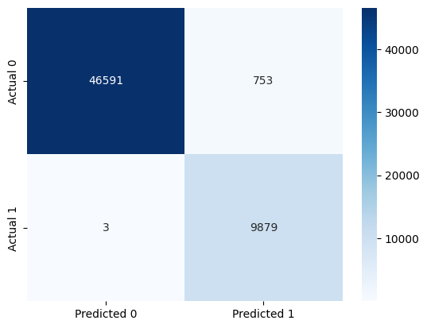

```python
# Performance metrics computation for the optimum decision threshold probability
#desired_threshold = 0.447

#y_pred_prob = model.predict_proba(X_train)[:,1]

# Classifying observations in the positive class (y = 1) if the predicted probability is greater
# than the desired decision threshold probability
#y_pred = y_pred_prob > desired_threshold
#y_pred = y_pred.astype(int)

#Computing the accuracy and recall
print('Train Scores')
print("Accuracy: ",accuracy_score(y_train, model.predict(X_train_filtered))*100)
print("Recall: ", recall_score(y_train, model.predict(X_train_filtered))*100)
print("Precision: ", precision_score(y_train, model.predict(X_train_filtered))*100)

#Confusion matrix
cm = pd.DataFrame(confusion_matrix(y_train, model.predict(X_train_filtered)),
                  columns=['Predicted 0', 'Predicted 1'], index = ['Actual 0', 'Actual 1'])
sns.heatmap(cm, annot=True, cmap='Blues', fmt='g');
```

```
Test Scores
Accuracy:  91.87810162857343
Recall:  82.11317768104472
Precision:  74.50628366247756
```

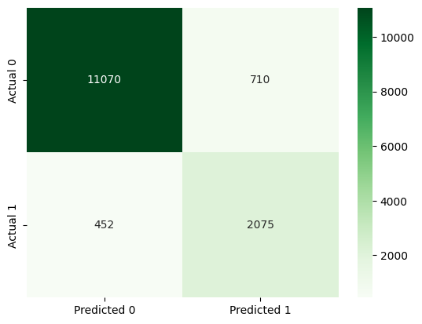

```python
#Computing the accuracy and recall
print('Test Scores')
print("Accuracy: ", accuracy_score(y_test, model.predict(X_test_filtered))*100)
print("Recall: ", recall_score(y_test, model.predict(X_test_filtered))*100)
print("Precision: ", precision_score(y_test, model.predict(X_test_filtered))*100)

#Confusion matrix
cm = pd.DataFrame(confusion_matrix(y_test, model.predict(X_test_filtered)),
                  columns=['Predicted 0', 'Predicted 1'], index = ['Actual 0', 'Actual 1'])
sns.heatmap(cm, annot=True, cmap='Greens', fmt='g');
```

*Search A.2*

```python
# Optimal estimators search
param_grid = {'n_estimators': [1000, 1500, 2000],
              'learning_rate': [0.01, 0.1],
              'max_depth': range(15, 18),
              'subsample': [0.5, 0.55],
              'gamma': [6, 7, 8],
              'reg_lambda': [1, 1.5, 2],
              'colsample_bytree': [0.5, 0.75],
              'scale_pos_weight': [scale_pos_weight]}

# Defining the evaluation procedure
cv = StratifiedKFold(n_splits = 5, shuffle = True)

# Defining the grid search procedure
grid_search = RandomizedSearchCV(estimator = xgb.XGBClassifier(), param_distributions = param_grid, n_iter=20, n_jobs = -1, cv = cv,
                          verbose = True, scoring = ['accuracy', 'recall'], refit = 'accuracy')
# execute the grid search
grid_result = grid_search.fit(X_train_filtered, y_train)

# summarize the best score and configuration
print("Best: %f using %s" % (grid_result.best_score_, grid_result.best_params_))
```

```
Fitting 5 folds for each of 20 candidates, totalling 100 fits
```

```
Best: 0.908398 using {'subsample': 0.55, 'scale_pos_weight': 4.790933009512244, 'reg_lambda': 2, 'n_estimators': 1500, 'max_depth': 17, 'learning_rate': 0.1, 'gamma': 6, 'colsample_bytree': 0.75}
```

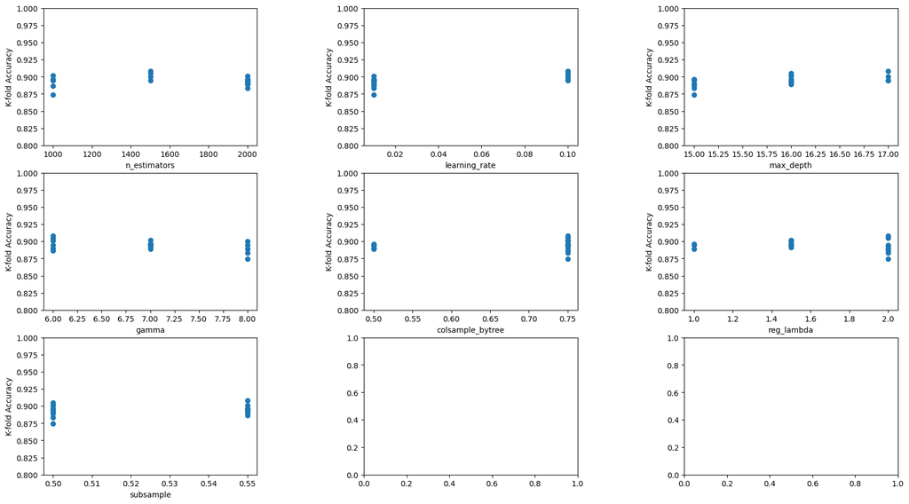

```python
# Graphing hyperparam values vs. accuracy
cv_results = pd.DataFrame(grid_search.cv_results_)
cv_results.head();

fig, axes = plt.subplots(3, 3, figsize=(20,11))
plt.subplots_adjust(wspace = 0.5)
axes[0, 0].plot(cv_results.param_n_estimators, cv_results.mean_test_accuracy, 'o')
axes[0, 0].set_ylim([0.8, 1])
axes[0, 0].set_xlabel('n_estimators')
axes[0, 0].set_ylabel('K-fold Accuracy')
axes[0, 1].plot(cv_results.param_learning_rate, cv_results.mean_test_accuracy, 'o')
axes[0, 1].set_ylim([0.8, 1])
axes[0, 1].set_xlabel('learning_rate')
axes[0, 1].set_ylabel('K-fold Accuracy');
axes[0, 2].plot(cv_results.param_max_depth, cv_results.mean_test_accuracy, 'o')
axes[0, 2].set_ylim([0.8, 1])
axes[0, 2].set_xlabel('max_depth')
axes[0, 2].set_ylabel('K-fold Accuracy');
axes[1, 0].plot(cv_results.param_gamma, cv_results.mean_test_accuracy, 'o')
axes[1, 0].set_ylim([0.8, 1])
axes[1, 0].set_xlabel('gamma')
axes[1, 0].set_ylabel('K-fold Accuracy');
axes[1, 1].plot(cv_results.param_colsample_bytree, cv_results.mean_test_accuracy, 'o')
axes[1, 1].set_ylim([0.8, 1])
axes[1, 1].set_xlabel('colsample_bytree')
axes[1, 1].set_ylabel('K-fold Accuracy');
axes[1, 2].plot(cv_results.param_reg_lambda, cv_results.mean_test_accuracy, 'o')
axes[1, 2].set_ylim([0.8, 1])
axes[1, 2].set_xlabel('reg_lambda')
axes[1, 2].set_ylabel('K-fold Accuracy');
axes[2, 0].plot(cv_results.param_subsample, cv_results.mean_test_accuracy, 'o')
axes[2, 0].set_ylim([0.8, 1])
axes[2, 0].set_xlabel('subsample')
axes[2, 0].set_ylabel('K-fold Accuracy');
```

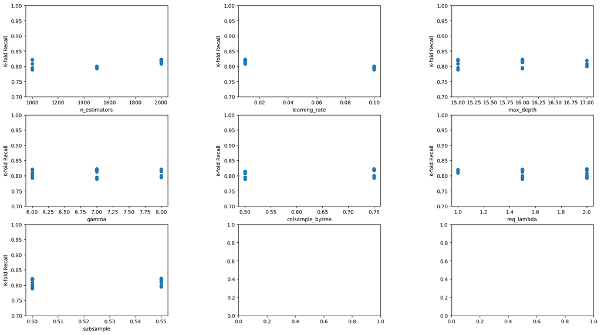

```python
# Graphing hyperparam values vs. recall
fig, axes = plt.subplots(3, 3, figsize=(20,11))
plt.subplots_adjust(wspace = 0.5)
axes[0, 0].plot(cv_results.param_n_estimators, cv_results.mean_test_recall, 'o')
axes[0, 0].set_ylim([0.7, 1])
axes[0, 0].set_xlabel('n_estimators')
axes[0, 0].set_ylabel('K-fold Recall')
axes[0, 1].plot(cv_results.param_learning_rate, cv_results.mean_test_recall, 'o')
axes[0, 1].set_ylim([0.7, 1])
axes[0, 1].set_xlabel('learning_rate')
axes[0, 1].set_ylabel('K-fold Recall');
axes[0, 2].plot(cv_results.param_max_depth, cv_results.mean_test_recall, 'o')
axes[0, 2].set_ylim([0.7, 1])
axes[0, 2].set_xlabel('max_depth')
axes[0, 2].set_ylabel('K-fold Recall');
axes[1, 0].plot(cv_results.param_gamma, cv_results.mean_test_recall, 'o')
axes[1, 0].set_ylim([0.7, 1])
axes[1, 0].set_xlabel('gamma')
axes[1, 0].set_ylabel('K-fold Recall');
axes[1, 1].plot(cv_results.param_colsample_bytree, cv_results.mean_test_recall, 'o')
axes[1, 1].set_ylim([0.7, 1])
axes[1, 1].set_xlabel('colsample_bytree')
axes[1, 1].set_ylabel('K-fold Recall');
axes[1, 2].plot(cv_results.param_reg_lambda, cv_results.mean_test_recall, 'o')
axes[1, 2].set_ylim([0.7, 1])
axes[1, 2].set_xlabel('reg_lambda')
axes[1, 2].set_ylabel('K-fold Recall');
axes[2, 0].plot(cv_results.param_subsample, cv_results.mean_test_recall, 'o')
axes[2, 0].set_ylim([0.7, 1])
axes[2, 0].set_xlabel('subsample')
axes[2, 0].set_ylabel('K-fold Recall');
```

*Model A.2, from Search A.2*

```python
# Fitting model with optimals from Randomized
model2 = xgb.XGBClassifier(max_depth = 17, subsample = 0.55, scale_pos_weight = scale_pos_weight, reg_lambda = 2, n_estimators = 1500, learning_rate = 0.1, gamma = 6, colsample_bytree = 0.75).fit(X_train_filtered, y_train)
```

```
Test Scores
Accuracy:  92.32543510169847
Recall:  82.50890383854372
Precision:  76.06712878511492
```

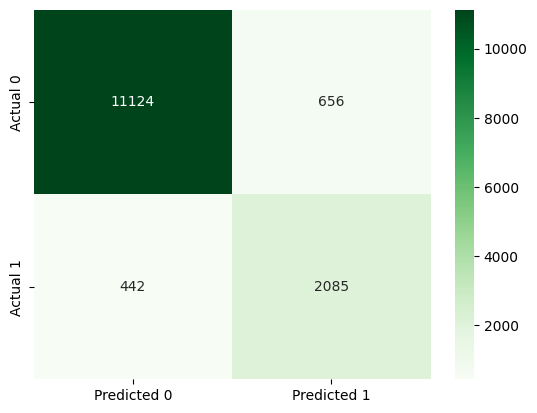

```python
#Computing the accuracy and recall
print('Test Scores')
print("Accuracy: ", accuracy_score(y_test, model2.predict(X_test_filtered))*100)
print("Recall: ", recall_score(y_test, model2.predict(X_test_filtered))*100)
print("Precision: ", precision_score(y_test, model2.predict(X_test_filtered))*100)

#Confusion matrix
cm = pd.DataFrame(confusion_matrix(y_test, model2.predict(X_test_filtered)),
                  columns=['Predicted 0', 'Predicted 1'], index = ['Actual 0', 'Actual 1'])
sns.heatmap(cm, annot=True, cmap='Greens', fmt='g');
```

*Search A.3:* *Attempt at a higher value of* `max_features`, *refitting on accuracy*

```python
# Optimal estimators search
param_grid = {'n_estimators': [1500],
              'learning_rate': [0.1],
              'max_depth': range(17, 23),
              'subsample': [0.5, 0.55],
              'gamma': [5, 6],
              'reg_lambda': [2, 2.5],
              'colsample_bytree': [0.75, 0.9],
              'scale_pos_weight': [scale_pos_weight]}

# Defining the evaluation procedure
cv = StratifiedKFold(n_splits = 2, shuffle = True)

# Defining the grid search procedure
grid_search = RandomizedSearchCV(estimator = xgb.XGBClassifier(n_jobs = -1), param_distributions = param_grid, n_iter=10, n_jobs = -1, cv = cv,
                          verbose = True, scoring = ['accuracy', 'recall'], refit = 'accuracy')
# execute the grid search
grid_result = grid_search.fit(X_train_filtered, y_train)

# summarize the best score and configuration
print("Best: %f using %s" % (grid_result.best_score_, grid_result.best_params_))
```

```
Fitting 2 folds for each of 10 candidates, totalling 20 fits
Best: 0.887534 using {'subsample': 0.55, 'scale_pos_weight': 4.790933009512244, 'reg_lambda': 2, 'n_estimators': 1500, 'max_depth': 22, 'learning_rate': 0.1, 'gamma': 5, 'colsample_bytree': 0.9}
```

```python
modetest = xgb.XGBClassifier(max_depth = 22,
                           subsample = 0.55,
                           scale_pos_weight = scale_pos_weight,
                           reg_lambda = 2, n_estimators = 1500,
                           learning_rate = 0.1,
                           gamma = 5,
                           colsample_bytree = 0.75, n_jobs = -1).fit(X_train_filtered, y_train)
```

```
Test Scores
Accuracy:  92.81470608792898
Recall:  81.91531460229521
Precision:  78.37940174176448
```

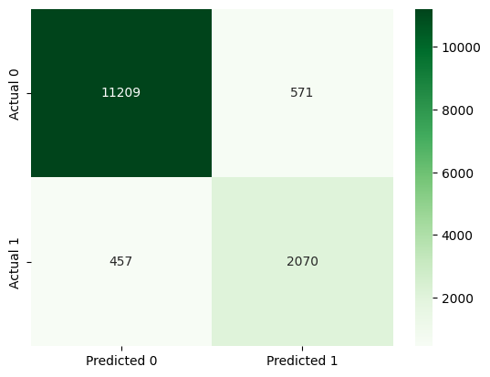

```python
#Computing the accuracy and recall
print('Test Scores')
print("Accuracy: ", accuracy_score(y_test, modetest.predict(X_test_filtered))*100)
print("Recall: ", recall_score(y_test, modetest.predict(X_test_filtered))*100)
print("Precision: ", precision_score(y_test, modetest.predict(X_test_filtered))*100)

#Confusion matrix
cm = pd.DataFrame(confusion_matrix(y_test, modetest.predict(X_test_filtered)),
                  columns=['Predicted 0', 'Predicted 1'], index = ['Actual 0', 'Actual 1'])
sns.heatmap(cm, annot=True, cmap='Greens', fmt='g');
```

*Failed full* `GridSearchCV()` *for refitting on accuracy and testing maximum features, for some reason the GCE VM could not handle the dataset or code, and would break after 5 hours.*

```python
# Optimal estimators search
param_grid = {'n_estimators': [1500],
              'learning_rate': [0.1],
              'max_depth': [22],
              'subsample': [0.5, 0.55, 0.6],
              'gamma': [4, 5, 6],
              'reg_lambda': [2],
              'colsample_bytree': [0.75, 0.9],
              'scale_pos_weight': [scale_pos_weight]}

# Defining the evaluation procedure
cv = StratifiedKFold(n_splits = 2, shuffle = True)

# Defining the grid search procedure
grid_search = GridSearchCV(estimator = xgb.XGBClassifier(n_jobs = -1), param_grid = param_grid, n_jobs = -1, cv = cv,
                          verbose = True, scoring = ['accuracy', 'recall'], refit = 'accuracy')
# execute the grid search
grid_result = grid_search.fit(X_train_filtered, y_train)

# summarize the best score and configuration
print("Best: %f using %s" % (grid_result.best_score_, grid_result.best_params_))
```

R. XGBoost Models Refitting on Recall

*Search R.1*

```python
# Optimal estimators search for refitting on recall
param_grid = {'n_estimators': [1500, 2000, 3000, 3500],
              'learning_rate': [0.001, 0.01, 0.1],
              'max_depth': range(16, 19),
              'subsample': [0.53, 0.55, 0.56],
              'gamma': [6, 7, 8],
              'reg_lambda': [1.5, 2, 3],
              'colsample_bytree': [0.5, 0.75, 0.9],
              'scale_pos_weight': [scale_pos_weight]}

# Defining the evaluation procedure
cv = StratifiedKFold(n_splits = 5, shuffle = True)

# Defining the grid search procedure
grid_search = RandomizedSearchCV(estimator = xgb.XGBClassifier(), param_distributions = param_grid, n_iter=25, n_jobs = -1, cv = cv,
                          verbose = True, scoring = ['accuracy', 'recall'], refit = 'recall')
# execute the grid search
grid_result = grid_search.fit(X_train_filtered, y_train)

# summarize the best score and configuration
print("Best: %f using %s" % (grid_result.best_score_, grid_result.best_params_))
```

```
Fitting 5 folds for each of 25 candidates, totalling 125 fits
```

```
Best: 0.828578 using {'subsample': 0.55, 'scale_pos_weight': 4.790933009512244, 'reg_lambda': 3, 'n_estimators': 2000, 'max_depth': 18, 'learning_rate': 0.01, 'gamma': 8, 'colsample_bytree': 0.9}
```

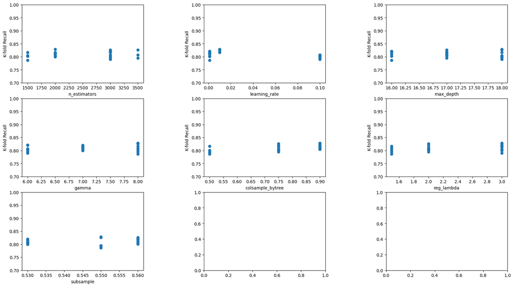

```python
cv_results = pd.DataFrame(grid_search.cv_results_)
cv_results.head();

fig, axes = plt.subplots(3, 3, figsize=(20,11))
plt.subplots_adjust(wspace = 0.5)
axes[0, 0].plot(cv_results.param_n_estimators, cv_results.mean_test_recall, 'o')
axes[0, 0].set_ylim([0.7, 1])
axes[0, 0].set_xlabel('n_estimators')
axes[0, 0].set_ylabel('K-fold Recall')
axes[0, 1].plot(cv_results.param_learning_rate, cv_results.mean_test_recall, 'o')
axes[0, 1].set_ylim([0.7, 1])
axes[0, 1].set_xlabel('learning_rate')
axes[0, 1].set_ylabel('K-fold Recall');
axes[0, 2].plot(cv_results.param_max_depth, cv_results.mean_test_recall, 'o')
axes[0, 2].set_ylim([0.7, 1])
axes[0, 2].set_xlabel('max_depth')
axes[0, 2].set_ylabel('K-fold Recall');
axes[1, 0].plot(cv_results.param_gamma, cv_results.mean_test_recall, 'o')
axes[1, 0].set_ylim([0.7, 1])
axes[1, 0].set_xlabel('gamma')
axes[1, 0].set_ylabel('K-fold Recall');
axes[1, 1].plot(cv_results.param_colsample_bytree, cv_results.mean_test_recall, 'o')
axes[1, 1].set_ylim([0.7, 1])
axes[1, 1].set_xlabel('colsample_bytree')
axes[1, 1].set_ylabel('K-fold Recall');
axes[1, 2].plot(cv_results.param_reg_lambda, cv_results.mean_test_recall, 'o')
axes[1, 2].set_ylim([0.7, 1])
axes[1, 2].set_xlabel('reg_lambda')
axes[1, 2].set_ylabel('K-fold Recall');
axes[2, 0].plot(cv_results.param_subsample, cv_results.mean_test_recall, 'o')
axes[2, 0].set_ylim([0.7, 1])
axes[2, 0].set_xlabel('subsample')
```

*Model R.1, from Search R.1*

```python
# Fitting model with optimals from Randomized for Recall
model4 = xgb.XGBClassifier(max_depth = 18, subsample = 0.55, scale_pos_weight = scale_pos_weight, reg_lambda = 3, n_estimators = 2000, learning_rate = 0.01, gamma = 8, colsample_bytree = 0.9).fit(X_train_filtered, y_train)
```

```
Test Scores
Accuracy:  90.4662053540225
Recall:  84.72497032053819
Precision:  68.6437960884899
```

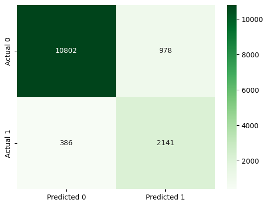

```python
#Computing the accuracy and recall
print('Test Scores')
print("Accuracy: ", accuracy_score(y_test, model4.predict(X_test_filtered))*100)
print("Recall: ", recall_score(y_test, model4.predict(X_test_filtered))*100)
print("Precision: ", precision_score(y_test, model4.predict(X_test_filtered))*100)

#Confusion matrix
cm = pd.DataFrame(confusion_matrix(y_test, model4.predict(X_test_filtered)),
                  columns=['Predicted 0', 'Predicted 1'], index = ['Actual 0', 'Actual 1'])
sns.heatmap(cm, annot=True, cmap='Greens', fmt='g');
```

Decision Threshold Probability (DTP) Tuning for Best Models

*DTP Tuning for Model A.2*

```python
from sklearn.metrics import roc_curve, precision_recall_curve, auc, make_scorer, recall_score, accuracy_score, precision_score, confusion_matrix

# KFold probabilities
cross_val_prob = cross_val_predict(model2, X_train_filtered, y_train, method = 'predict_proba', n_jobs = -1, cv = 5)

# Getting p, r, thresholds, (by function) and accuracies (by for loop)
p, r, thresholds = precision_recall_curve(y_train, cross_val_prob[:,1])

accuracies = []

for threshold in thresholds:
    predicted_class = cross_val_prob[:,1] > threshold
    predicted_class = predicted_class.astype(int)

    #Computing optimals
    accuracies = accuracies + [accuracy_score(y_train, predicted_class)]
```

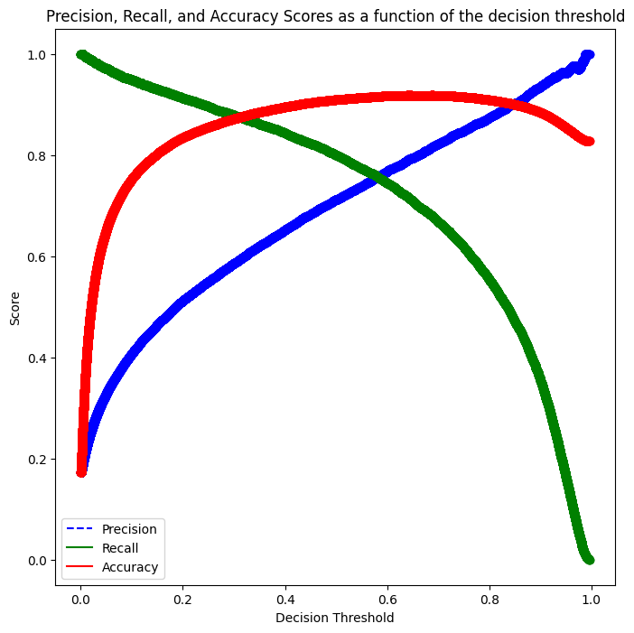

```python
# Plotting function
def plot_precision_recall_vs_threshold(precisions, recalls, accuracies, thresholds):
    plt.figure(figsize=(8, 8))
    plt.title("Precision, Recall, and Accuracy Scores as a function of the decision threshold")
    plt.plot(thresholds, precisions[:-1], "b--", label="Precision")
    plt.plot(thresholds, recalls[:-1], "g-", label="Recall")
    plt.plot(thresholds, accuracies, "r-", label="Accuracy")
    plt.plot(thresholds, precisions[:-1], "o", color = 'blue')
    plt.plot(thresholds, recalls[:-1], "o", color = 'green')
    plt.plot(thresholds, accuracies, "o", color = 'red')
    plt.plot
    plt.ylabel("Score")
    plt.xlabel("Decision Threshold")
    plt.legend(loc='best')
    plt.legend()
plot_precision_recall_vs_threshold(p, r, accuracies, thresholds)
```

```python
# Testing thresholds
metrics_iter = pd.DataFrame(columns = ['threshold', 'recall', 'accuracy'])
threshold_hyperparam_vals = np.arange(0.3, 0.5, 0.001)
iter_number = 0

for threshold_prob in threshold_hyperparam_vals:
    predicted_class = cross_val_prob[:,1] > threshold_prob
    predicted_class = predicted_class.astype(int)

    #Computing optimals
    accuracy = accuracy_score(y_train, predicted_class)
    recall = recall_score(y_train, predicted_class)
    metrics_iter.loc[iter_number, 'threshold'] = threshold_prob
    metrics_iter.loc[iter_number, 'recall'] = recall
    metrics_iter.loc[iter_number, 'accuracy'] = accuracy
    iter_number = iter_number + 1
```

```python
new = metrics_iter[metrics_iter.accuracy >= 0.90]
new[new.recall >= 0.83]
```

|  | threshold | recall | accuracy |
| --- | --- | --- | --- |
| 128 | 0.428 | 0.831411 | 0.900203 |
| 129 | 0.429 | 0.830905 | 0.900325 |
| 130 | 0.43 | 0.830905 | 0.900692 |
| 131 | 0.431 | 0.830095 | 0.900779 |

```
Test Scores
Accuracy:  91.54959110924722
Recall:  85.1602690937871
Precision:  72.06965840589417
```

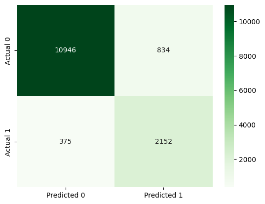

```python
# Performance metrics computation for the optimum decision threshold probability
desired_threshold = 0.431 # An optimum threshold

y_pred_prob = model2.predict_proba(X_test_filtered)[:,1]

# Classifying observations in the positive class (y = 1) if the predicted probability is greater
# than the desired decision threshold probability
y_pred = y_pred_prob > desired_threshold
y_pred = y_pred.astype(int)

#Computing the accuracy and recall
print('Test Scores')
print("Accuracy: ", accuracy_score(y_test, y_pred)*100)
print("Recall: ", recall_score(y_test, y_pred)*100)
print("Precision: ", precision_score(y_test, y_pred)*100)

#Confusion matrix
cm = pd.DataFrame(confusion_matrix(y_test, y_pred),
                  columns=['Predicted 0', 'Predicted 1'], index = ['Actual 0', 'Actual 1'])
sns.heatmap(cm, annot=True, cmap='Greens', fmt='g');
```

```python
from sklearn.metrics import roc_curve, precision_recall_curve, auc, make_scorer, recall_score, accuracy_score, precision_score, confusion_matrix


# KFold probabilities
cross_val_prob4 = cross_val_predict(model4, X_train_filtered, y_train, method = 'predict_proba', n_jobs = -1, cv = 5)

# Getting p, r, thresholds, (by function) and accuracies (by for loop)
p4, r4, thresholds4 = precision_recall_curve(y_train, cross_val_prob4[:,1])

accuracies4 = []

for threshold in thresholds4:
    predicted_class = cross_val_prob4[:,1] > threshold
    predicted_class = predicted_class.astype(int)

    #Computing optimals
    accuracies4 = accuracies4 + [accuracy_score(y_train, predicted_class)]
```

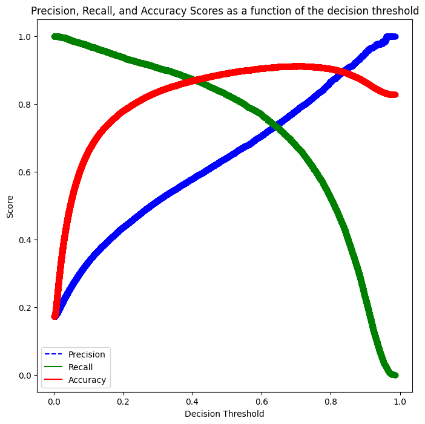

```python
# Plotting function
def plot_precision_recall_vs_threshold(precisions, recalls, accuracies, thresholds):
    plt.figure(figsize=(8, 8))
    plt.title("Precision, Recall, and Accuracy Scores as a function of the decision threshold")
    plt.plot(thresholds, precisions[:-1], "b--", label="Precision")
    plt.plot(thresholds, recalls[:-1], "g-", label="Recall")
    plt.plot(thresholds, accuracies, "r-", label="Accuracy")
    plt.plot(thresholds, precisions[:-1], "o", color = 'blue')
    plt.plot(thresholds, recalls[:-1], "o", color = 'green')
    plt.plot(thresholds, accuracies, "o", color = 'red')
    plt.plot
    plt.ylabel("Score")
    plt.xlabel("Decision Threshold")
    plt.legend(loc='best')
    plt.legend()

plot_precision_recall_vs_threshold(p4, r4, accuracies4, thresholds4)
```

```python
# Testing thresholds
metrics_iter = pd.DataFrame(columns = ['threshold', 'recall', 'accuracy'])
threshold_hyperparam_vals = np.arange(0.3, 0.5, 0.001)
iter_number = 0

for threshold_prob in threshold_hyperparam_vals:
    predicted_class = cross_val_prob4[:,1] > threshold_prob
    predicted_class = predicted_class.astype(int)

    #Computing optimals
    accuracy = accuracy_score(y_train, predicted_class)
    recall = recall_score(y_train, predicted_class)
    metrics_iter.loc[iter_number, 'threshold'] = threshold_prob
    metrics_iter.loc[iter_number, 'recall'] = recall
    metrics_iter.loc[iter_number, 'accuracy'] = accuracy
    iter_number = iter_number + 1
```

```python
new = metrics_iter[metrics_iter.recall >= 0.85]
new[new.accuracy >= 0.88]
```

|  | threshold | recall | accuracy |
| --- | --- | --- | --- |
| 150 | 0.45 | 0.850739 | 0.880247 |
| 151 | 0.451 | 0.850132 | 0.880561 |
| 152 | 0.452 | 0.85003 | 0.880754 |

```
Test Scores
Accuracy:  91.79422660236249
Recall:  84.44796201028888
Precision:  73.20754716981132
```

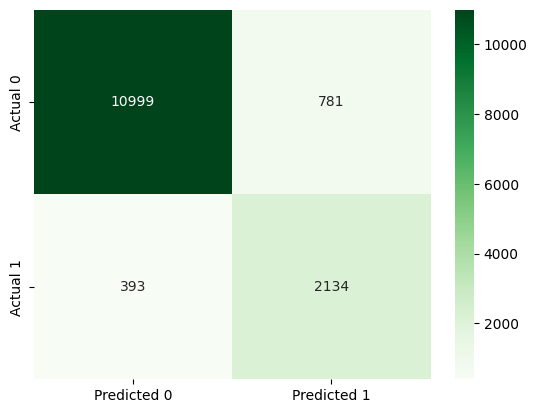

```python
# Performance metrics computation for the optimum decision threshold probability
desired_threshold = 0.452

y_pred_prob = model2.predict_proba(X_test_filtered)[:,1]

# Classifying observations in the positive class (y = 1) if the predicted probability is greater
# than the desired decision threshold probability
y_pred = y_pred_prob > desired_threshold
y_pred = y_pred.astype(int)

#Computing the accuracy and recall
print('Test Scores')
print("Accuracy: ", accuracy_score(y_test, y_pred)*100)
print("Recall: ", recall_score(y_test, y_pred)*100)
print("Precision: ", precision_score(y_test, y_pred)*100)

#Confusion matrix
cm = pd.DataFrame(confusion_matrix(y_test, y_pred),
                  columns=['Predicted 0', 'Predicted 1'], index = ['Actual 0', 'Actual 1'])
sns.heatmap(cm, annot=True, cmap='Greens', fmt='g');
```

## 4 Outlier Detection for AdaBoost, coded for Lila’s usage.

```python
# Identify outliers in the training dataset
from sklearn.ensemble import IsolationForest
iso = IsolationForest(n_jobs = -1)
yhat = iso.fit_predict(X_train_filtered)
```

```python
# Filter for observations determined as outliers by IsolationTree()
mask = yhat != -1
X_train_noout, y_train_noout = X_train_filtered.loc[mask, :], y_train[mask]
```

```python
# Uploading as csv's to share with Lila, AdaBoost developer
X_train_noout.to_csv('X_train_tree_noout.csv')
y_train_noout.to_csv('y_train_tree_noout.csv')
```

## 5 Initial Model: Possible Interest in CatBoost

```python
%%capture
pip install catboost
```

```python
from lightgbm import LGBMRegressor
from catboost import CatBoostRegressor, CatBoostClassifier
```

Baseline CatBoost Model Performance

```python
cbmodel = CatBoostClassifier(verbose = False).fit(X_train_filtered, y_train)
```

```
Train Scores
Accuracy:  91.80092964736308
Recall:  61.51588747217163
Precision:  87.24167623421354
```

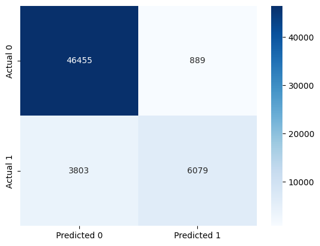

```python
print('Train Scores')
print("Accuracy: ",accuracy_score(y_train, cbmodel.predict(X_train_filtered))*100)
print("Recall: ", recall_score(y_train, cbmodel.predict(X_train_filtered))*100)
print("Precision: ", precision_score(y_train, cbmodel.predict(X_train_filtered))*100)

#Confusion matrix
cm = pd.DataFrame(confusion_matrix(y_train, cbmodel.predict(X_train_filtered)),
                  columns=['Predicted 0', 'Predicted 1'], index = ['Actual 0', 'Actual 1'])
sns.heatmap(cm, annot=True, cmap='Blues', fmt='g');
```

```
Test Scores
Accuracy:  89.26399664499895
Recall:  52.07756232686981
Precision:  80.19500304692261
```

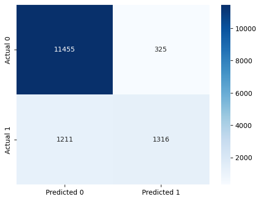

```python
#Computing the accuracy and recall
print('Test Scores')
print("Accuracy: ", accuracy_score(y_test, cbmodel.predict(X_test_filtered))*100)
print("Recall: ", recall_score(y_test, cbmodel.predict(X_test_filtered))*100)
print("Precision: ", precision_score(y_test, cbmodel.predict(X_test_filtered))*100)

#Confusion matrix
cm = pd.DataFrame(confusion_matrix(y_test, cbmodel.predict(X_test_filtered)),
                  columns=['Predicted 0', 'Predicted 1'], index = ['Actual 0', 'Actual 1'])
sns.heatmap(cm, annot=True, cmap='Blues', fmt='g');
```

## 6 Conclusions and Recommendations to stakeholder(s)

*Model A.2 Feature Importances*

```python
importances = model2.feature_importances_
importances = pd.DataFrame(importances)

df = pd.concat([pd.DataFrame(model2.feature_names_in_, columns = ['Predictors']), importances], axis = 1)
df = df.rename(columns = {0: 'Importances'})
df.set_index('Predictors').sort_values(by = 'Importances', ascending = False)
```

| Predictors | Importances |
| --- | --- |
| HEFAMINC | 0.168414 |
| HETENURE | 0.088783 |
| HXFAMINC | 0.085418 |
| HRNUMHOU | 0.060304 |
| HRHTYPE | 0.047377 |
| PEEDUCA | 0.045405 |
| GESTFIPS | 0.035706 |
| GTCBSASZ | 0.035083 |
| GTCO | 0.033834 |
| GTCSA | 0.033716 |
| GTCBSA | 0.033610 |
| HRMIS | 0.033280 |
| GEDIV | 0.032151 |
| PRTAGE | 0.032099 |
| HRHHID2 | 0.031603 |
| HWHHWGT | 0.030907 |
| PWVETWGT | 0.030068 |
| QSTNUM | 0.029660 |
| PWSSWGT | 0.028817 |
| PWFMWGT | 0.028548 |
| PWLGWGT | 0.028358 |
| PWCMPWGT | 0.026859 |

*Model R.1 Feature Importances*

```python
importances4 = model4.feature_importances_
importances4 = pd.DataFrame(importances4)

df4 = pd.concat([pd.DataFrame(model4.feature_names_in_, columns = ['Predictors']), importances4], axis = 1)
df4 = df4.rename(columns = {0: 'Importances'})
df4.set_index('Predictors').sort_values(by = 'Importances', ascending = False)
```

[output not shown]